# Stereo-seq Reference18 K=6 Factor Validation

**Raw-expression validation and patient-level metrics for frozen per-chip Neighborhood NMF factors**

This report reuses the frozen K=6 NMF outputs. It does not refit RCTD or NMF, perform disease comparisons, or alter the 238 frozen lymphoid aggregates. All reported values are loaded dynamically from the completed analysis outputs.

## Reproducible render command

```
TS=$(date +%y%m%d%H%M%S)
PROJ='/mnt/d/Lung ST/codex agent/stereo_seq/stereo_seq'
/home/bozhu/miniconda3/envs/stereo/bin/jupyter nbconvert --to html --execute \
  "$PROJ/scripts/1103_k6_factor_downstream_report.ipynb" \
  --ExecutePreprocessor.timeout=600 \
  --output "1103_k6_factor_downstream_report_${TS}.html" \
  --output-dir "$PROJ/results" \
  > "$PROJ/logs/1103_k6_factor_downstream_report_${TS}.log" 2>&1
```

```python
from pathlib import Path
import pandas as pd
from IPython.display import Image, Markdown, display

relative_run_dir = Path('results/reanalysis/REFERENCE18_K6_FACTOR_DOWNSTREAM_20261013_003020')
project_root = next(
    root for root in [Path.cwd(), *Path.cwd().parents]
    if (root / relative_run_dir / 'COMPLETE.ok').exists()
)
run_dir = project_root / relative_run_dir
assert (run_dir / 'COMPLETE.ok').exists(), run_dir

manifest = pd.read_csv(run_dir / '00_INPUT_MANIFEST.tsv', sep='\t')
factor_definitions = pd.read_csv(run_dir / '01_FACTOR_DEFINITIONS.tsv', sep='\t')
patient_metrics = pd.read_csv(run_dir / '02_PATIENT_FACTOR_METRICS.tsv', sep='\t')
patient_expression = pd.read_csv(run_dir / '03_PATIENT_FACTOR_RAW_EXPRESSION_VALIDATION.tsv', sep='\t')
expression_summary = pd.read_csv(run_dir / '04_FACTOR_RAW_EXPRESSION_SUMMARY.tsv', sep='\t')
marker_audit = pd.read_csv(run_dir / '05_MARKER_PANEL_AUDIT.tsv', sep='\t')
factor_table = pd.read_csv(run_dir / '06_FINAL_FACTOR_ANALYSIS_TABLE.tsv', sep='\t')
validation = pd.read_csv(run_dir / '08_VALIDATION.tsv', sep='\t')
pd.set_option('display.max_rows', 200)
pd.set_option('display.max_columns', 50)
```

## Scope and validation status

```python
scope = pd.DataFrame({
    'Measure': ['Chips', 'Patients', 'Factors', 'Evaluable neighborhoods', 'Patient-factor rows', 'Validation checks passed'],
    'Value': [
        factor_table['chip'].nunique(),
        patient_metrics['patient_id'].nunique(),
        len(factor_table),
        int(patient_metrics.drop_duplicates(['chip', 'patient_id'])['n_neighborhoods'].sum()),
        len(patient_metrics),
        f"{validation['status'].eq('PASS').sum()}/{len(validation)}",
    ]
})
display(scope)
display(validation)
```

|  | Measure | Value |
| --- | --- | --- |
| 0 | Chips | 3 |
| 1 | Patients | 21 |
| 2 | Factors | 18 |
| 3 | Evaluable neighborhoods | 126199 |
| 4 | Patient-factor rows | 126 |
| 5 | Validation checks passed | 20/20 |

|  | check | status | detail |
| --- | --- | --- | --- |
| 0 | factor definitions: 18 unique chip-factor rows | PASS | rows=18; unique_pairs=18 |
| 1 | expression summary: 18 unique chip-factor rows | PASS | rows=18; unique_pairs=18 |
| 2 | final table: 18 unique chip-factor rows | PASS | rows=18; unique_pairs=18 |
| 3 | patient metrics: all factors represented | PASS | unique_pairs=18 |
| 4 | patient metrics: 18 factors x 7 patients | PASS | rows=126 |
| 5 | patient metrics: seven patients per factor | PASS | range=7-7 |
| 6 | patient expression: all factors represented | PASS | unique_pairs=18 |
| 7 | patient expression: 18 factors x 7 patients | PASS | rows=126 |
| 8 | patient expression: seven patients per factor | PASS | range=7-7 |
| 9 | all 21 patients represented | PASS | n=21 |
| 10 | three chips represented | PASS | J2,K8,L3 |
| 11 | marker audit has 18 Reference18 states | PASS | rows=18 |
| 12 | every marker panel has raw-count genes | PASS | minimum=3 |
| 13 | critical patient metrics are finite | PASS | missing_values=0 |
| 14 | critical raw-expression metrics are finite | PASS | missing_values=0 |
| 15 | usage metrics have valid ranges | PASS | expected range 0-1 |
| 16 | four non-empty English audit figures | PASS | n=4 |
| 17 | run completion marker exists | PASS | /mnt/d/Lung ST/codex agent/stereo_seq/stereo_s... |
| 18 | input manifest exists | PASS | /mnt/d/Lung ST/codex agent/stereo_seq/stereo_s... |
| 19 | no disease-comparison or aggregate output created | PASS | none |

## Methods

- Factor usage and loadings came from the frozen per-chip Reference18 Neighborhood NMF K=6 models.
- Primary expression validation aggregated raw RNA over the same center-excluded 50 µm neighborhood used by NMF. Center-bin RNA was retained as independent focal evidence.
- Marker panels came from the six-dataset conservative Reference18 proposal.
- Marker-program associations were assessed within patient after adjustment for UMI, detected genes, and effective neighbor count.
- A complementary raw-count pseudobulk comparison matched high-usage bins to lower-usage bins on technical covariates.
- Patient metrics include continuous usage, balanced high-usage area, patient contribution, technical correlations, residual Moran's I, connected components, and local enrichment.
- Evidence labels summarize multiple axes and are not deletion gates or disease effects.

## Factor-level results

```python
evidence_counts = (factor_table['raw_expression_evidence']
                   .value_counts()
                   .rename_axis('Raw-expression evidence')
                   .reset_index(name='Factor count'))
display(evidence_counts)

factor_columns = [
    'chip', 'factor', 'top_state_1', 'top_state_2', 'top_state_3',
    'median_neighbor_composite_marker_residual_spearman',
    'median_composite_marker_log2fc',
    'positive_composite_marker_log2fc_patient_n',
    'patient_high_usage_coverage_n',
    'max_patient_mean_usage_contribution',
    'median_usage_umi_spearman', 'median_usage_n_genes_spearman',
    'raw_expression_evidence', 'final_evidence_level'
]
display(factor_table[factor_columns])
```

|  | Raw-expression evidence | Factor count |
| --- | --- | --- |
| 0 | Concordant raw-expression support | 9 |
| 1 | Neighborhood raw-expression support | 6 |
| 2 | Focal center-bin enrichment support | 1 |
| 3 | Concordant strong raw-expression support | 1 |
| 4 | Raw-expression support unresolved | 1 |

|  | chip | factor | top_state_1 | top_state_2 | top_state_3 | median_neighbor_composite_marker_residual_spearman | median_composite_marker_log2fc | positive_composite_marker_log2fc_patient_n | patient_high_usage_coverage_n | max_patient_mean_usage_contribution | median_usage_umi_spearman | median_usage_n_genes_spearman | raw_expression_evidence | final_evidence_level |
| --- | --- | --- | --- | --- | --- | --- | --- | --- | --- | --- | --- | --- | --- | --- |
| 0 | K8 | F01 | Lymphatic endothelial | Fibroblast | Myofibroblast | 0.064136 | 0.365916 | 5 | 7 | 0.154286 | -0.059918 | -0.059466 | Concordant raw-expression support | Partially reproducible factor |
| 1 | K8 | F02 | B | AT1 | Blood endothelial | 0.010638 | 0.098787 | 4 | 7 | 0.202633 | 0.074453 | 0.073124 | Concordant raw-expression support | Patient-specific candidate |
| 2 | K8 | F03 | Ciliated epithelial | NK | AT1 | 0.068458 | -0.124711 | 2 | 7 | 0.346703 | -0.124417 | -0.122667 | Neighborhood raw-expression support | Reproducible composition factor |
| 3 | K8 | F04 | Fibroblast | AT1 | Perivascular/mesothelial stromal | 0.034577 | 0.016762 | 4 | 7 | 0.187713 | 0.181791 | 0.182325 | Concordant raw-expression support | Reproducible composition factor |
| 4 | K8 | F05 | Perivascular/mesothelial stromal | B | AT1 | 0.148071 | 0.033387 | 5 | 7 | 0.158805 | -0.140216 | -0.140090 | Concordant raw-expression support | Unresolved |
| 5 | K8 | F06 | Blood endothelial | AT1 | T | 0.100033 | 0.000000 | 3 | 7 | 0.159543 | 0.003878 | 0.001452 | Neighborhood raw-expression support | Unresolved |
| 6 | J2 | F01 | AT1 | B | Myofibroblast | 0.086021 | 0.181161 | 5 | 7 | 0.161084 | 0.123810 | 0.122688 | Concordant raw-expression support | Reproducible composition factor |
| 7 | J2 | F02 | Lymphatic endothelial | Perivascular/mesothelial stromal | AT2/alveolar transitional | 0.097096 | 0.022101 | 4 | 7 | 0.151895 | -0.083940 | -0.082769 | Concordant raw-expression support | Reproducible composition factor |
| 8 | J2 | F03 | B | Perivascular/mesothelial stromal | Basal-like epithelial | 0.010962 | 1.158153 | 6 | 7 | 0.155418 | 0.002430 | 0.003982 | Concordant raw-expression support | Reproducible composition factor |
| 9 | J2 | F04 | Ciliated epithelial | AT1 | T | 0.063056 | 0.385189 | 6 | 7 | 0.174500 | -0.125020 | -0.121744 | Concordant raw-expression support | Partially reproducible factor |
| 10 | J2 | F05 | Blood endothelial | Perivascular/mesothelial stromal | AT2/alveolar transitional | 0.036154 | -0.000176 | 2 | 7 | 0.164189 | -0.032789 | -0.031206 | Neighborhood raw-expression support | Unresolved |
| 11 | J2 | F06 | Fibroblast | Blood endothelial | Lymphatic endothelial | 0.054129 | 0.112191 | 4 | 7 | 0.164001 | 0.184332 | 0.180507 | Concordant raw-expression support | Partially reproducible factor |
| 12 | L3 | F01 | B | Fibroblast | Ciliated epithelial | -0.004698 | 0.930512 | 6 | 7 | 0.173721 | 0.161232 | 0.163355 | Focal center-bin enrichment support | Reproducible composition factor |
| 13 | L3 | F02 | Ciliated epithelial | T | NK | 0.061620 | 0.000000 | 2 | 7 | 0.202351 | -0.042314 | -0.037192 | Neighborhood raw-expression support | Unresolved |
| 14 | L3 | F03 | AT1 | Myofibroblast | Fibroblast | 0.100531 | 0.713693 | 5 | 7 | 0.168736 | 0.205327 | 0.204639 | Concordant strong raw-expression support | Reproducible composition factor |
| 15 | L3 | F04 | Lymphatic endothelial | Fibroblast | Perivascular/mesothelial stromal | -0.018113 | 0.000000 | 2 | 7 | 0.159327 | 0.019160 | 0.017954 | Raw-expression support unresolved | Reproducible composition factor |
| 16 | L3 | F05 | Fibroblast | Blood endothelial | Mast/Basophil | 0.019908 | 0.000000 | 2 | 7 | 0.182847 | -0.082362 | -0.084219 | Neighborhood raw-expression support | Unresolved |
| 17 | L3 | F06 | Perivascular/mesothelial stromal | Blood endothelial | Mast/Basophil | 0.118989 | -0.000371 | 2 | 7 | 0.173503 | -0.158858 | -0.158011 | Neighborhood raw-expression support | Unresolved |

## B-associated factors

B-associated factors are retained as NMF results. This section distinguishes diffuse neighborhood-scale marker correlation from focal B-marker enrichment; weak continuous correlation does not by itself invalidate a localized B-rich factor.

```python
b_factors = factor_table.loc[factor_table['top_state_1'].eq('B'), [
    'chip', 'factor', 'median_neighbor_composite_marker_residual_spearman',
    'median_center_composite_marker_residual_spearman',
    'median_composite_marker_log2fc',
    'positive_composite_marker_log2fc_patient_n',
    'patient_high_usage_coverage_n', 'max_patient_mean_usage_contribution',
    'raw_expression_evidence', 'final_evidence_level'
]]
display(b_factors)
```

|  | chip | factor | median_neighbor_composite_marker_residual_spearman | median_center_composite_marker_residual_spearman | median_composite_marker_log2fc | positive_composite_marker_log2fc_patient_n | patient_high_usage_coverage_n | max_patient_mean_usage_contribution | raw_expression_evidence | final_evidence_level |
| --- | --- | --- | --- | --- | --- | --- | --- | --- | --- | --- |
| 1 | K8 | F02 | 0.010638 | -0.055230 | 0.098787 | 4 | 7 | 0.202633 | Concordant raw-expression support | Patient-specific candidate |
| 8 | J2 | F03 | 0.010962 | -0.008690 | 1.158153 | 6 | 7 | 0.155418 | Concordant raw-expression support | Reproducible composition factor |
| 12 | L3 | F01 | -0.004698 | -0.111665 | 0.930512 | 6 | 7 | 0.173721 | Focal center-bin enrichment support | Reproducible composition factor |

## English audit figures

Fig01 · Factor · Raw · Expression · Support

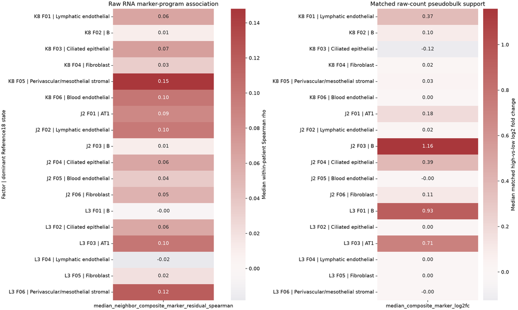

Fig02 · Expression · Support · By · Patient

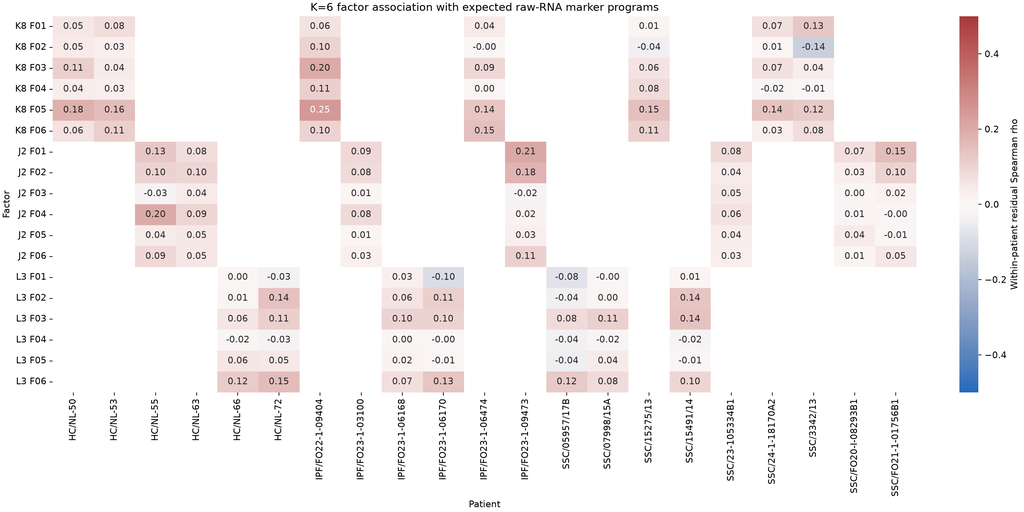

Fig03 · Factor · Patient · Level · Metrics

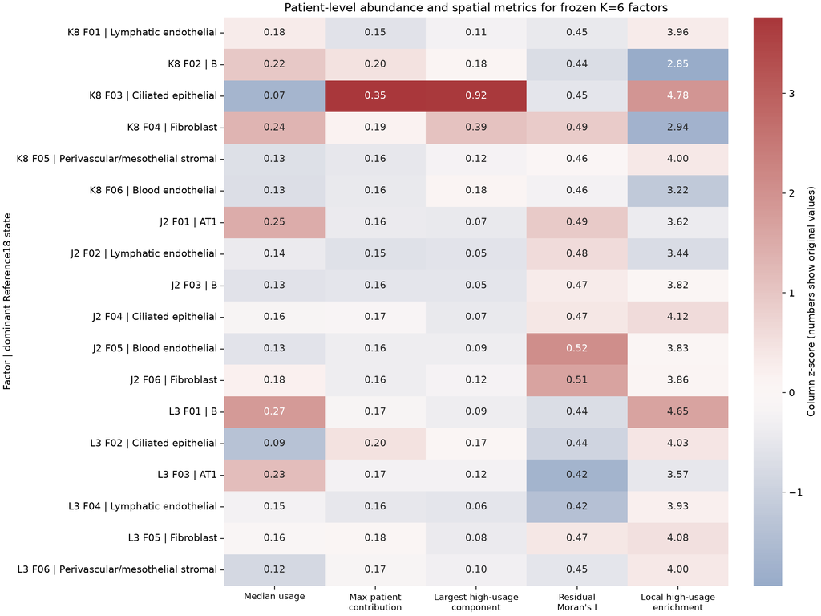

Fig04 · Factor · Technical · Associations

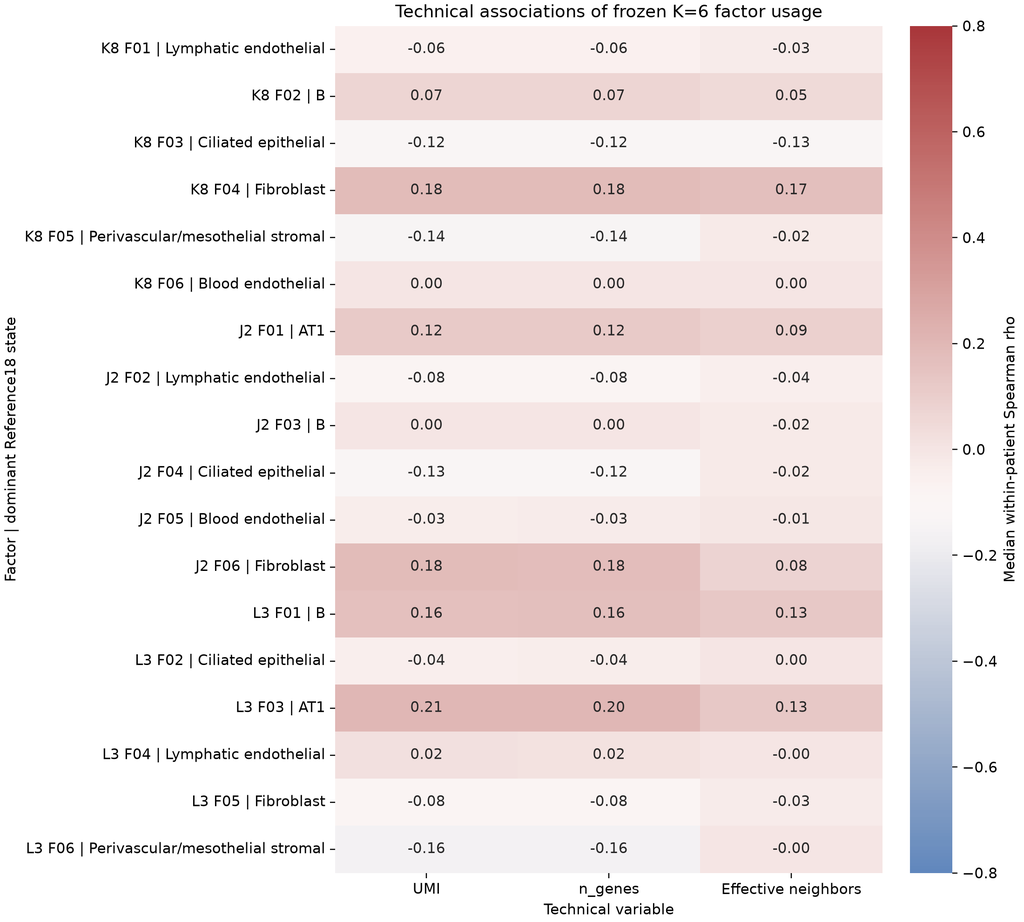

```python
figure_names = [
    'FIG01_FACTOR_RAW_EXPRESSION_SUPPORT.png',
    'FIG02_EXPRESSION_SUPPORT_BY_PATIENT.png',
    'FIG03_FACTOR_PATIENT_LEVEL_METRICS.png',
    'FIG04_FACTOR_TECHNICAL_ASSOCIATIONS.png',
]
for figure_name in figure_names:
    display(Markdown(f'### {figure_name.removesuffix(".png").replace("_", " · ").title()}'))
    display(Image(filename=str(run_dir / 'figures' / figure_name), width=1100))
```

## Patient-level metrics

The complete 126-row table is shown below. Disease labels are metadata only; no disease comparison is performed in this report.

```python
display(patient_metrics)
```

|  | chip | patient_id | disease | factor | n_neighborhoods | mean_usage | median_usage | usage_q90 | balanced_q90_cutoff | high_usage_fraction | dominant_factor_fraction | usage_umi_spearman | usage_n_genes_spearman | usage_neighbor_n_spearman | raw_usage_moran_i | technical_residual_usage_moran_i | high_usage_local_enrichment | high_usage_component_n | largest_high_component_fraction | median_high_component_size |
| --- | --- | --- | --- | --- | --- | --- | --- | --- | --- | --- | --- | --- | --- | --- | --- | --- | --- | --- | --- | --- |
| 0 | K8 | HC/NL-50 | HC | F01 | 4837 | 0.183651 | 0.181431 | 0.224047 | 0.224047 | 0.100062 | 0.028737 | -0.059454 | -0.054397 | -0.052992 | 0.476564 | 0.461122 | 3.960823 | 132 | 0.055785 | 2.0 |
| 1 | K8 | HC/NL-50 | HC | F02 | 4837 | 0.204722 | 0.204860 | 0.243213 | 0.267333 | 0.027083 | 0.021501 | 0.045896 | 0.052878 | 0.027016 | 0.500318 | 0.484927 | 9.657709 | 63 | 0.091603 | 1.0 |
| 2 | K8 | HC/NL-50 | HC | F03 | 4837 | 0.027982 | 0.025470 | 0.051218 | 0.110834 | 0.007029 | 0.000000 | -0.113458 | -0.107411 | -0.100575 | 0.519322 | 0.489116 | 73.530073 | 11 | 0.294118 | 2.0 |
| 3 | K8 | HC/NL-50 | HC | F04 | 4837 | 0.328981 | 0.329006 | 0.400601 | 0.295043 | 0.748811 | 0.934464 | 0.181532 | 0.174342 | 0.167422 | 0.616362 | 0.571667 | 1.152246 | 35 | 0.683600 | 1.0 |
| 4 | K8 | HC/NL-50 | HC | F05 | 4837 | 0.122788 | 0.118970 | 0.170781 | 0.179198 | 0.076080 | 0.011991 | -0.140216 | -0.140090 | -0.103693 | 0.483194 | 0.461540 | 5.290825 | 112 | 0.097826 | 1.0 |
| 5 | K8 | HC/NL-50 | HC | F06 | 4837 | 0.131875 | 0.130424 | 0.174353 | 0.176918 | 0.088071 | 0.003308 | 0.004753 | 0.001452 | 0.037433 | 0.482179 | 0.476259 | 4.007922 | 119 | 0.072770 | 1.0 |
| 6 | K8 | HC/NL-53 | HC | F01 | 2427 | 0.171174 | 0.169383 | 0.218615 | 0.224047 | 0.080758 | 0.044499 | -0.059918 | -0.059466 | -0.025548 | 0.481641 | 0.479012 | 4.452405 | 57 | 0.112245 | 2.0 |
| 7 | K8 | HC/NL-53 | HC | F02 | 2427 | 0.250402 | 0.252290 | 0.293474 | 0.267333 | 0.318088 | 0.518335 | 0.195550 | 0.193012 | 0.114981 | 0.456566 | 0.420048 | 1.741120 | 70 | 0.404145 | 2.0 |
| 8 | K8 | HC/NL-53 | HC | F03 | 2427 | 0.072517 | 0.067409 | 0.110834 | 0.110834 | 0.100124 | 0.003296 | -0.120966 | -0.122128 | -0.125847 | 0.538556 | 0.511181 | 4.783561 | 55 | 0.193416 | 2.0 |
| 9 | K8 | HC/NL-53 | HC | F04 | 2427 | 0.240248 | 0.243668 | 0.295043 | 0.295043 | 0.100124 | 0.402143 | 0.181791 | 0.182325 | 0.088536 | 0.478071 | 0.453346 | 3.590255 | 71 | 0.061728 | 1.0 |
| 10 | K8 | HC/NL-53 | HC | F05 | 2427 | 0.129400 | 0.126094 | 0.179198 | 0.179198 | 0.100124 | 0.013597 | -0.151518 | -0.150478 | 0.005029 | 0.473207 | 0.444932 | 3.995062 | 67 | 0.119342 | 1.0 |
| 11 | K8 | HC/NL-53 | HC | F06 | 2427 | 0.136259 | 0.134871 | 0.185276 | 0.176918 | 0.142151 | 0.018129 | -0.044809 | -0.042987 | 0.002213 | 0.523169 | 0.518403 | 3.215045 | 76 | 0.214493 | 1.0 |
| 12 | K8 | IPF/FO22-1-09404 | IPF | F01 | 6253 | 0.196599 | 0.195849 | 0.221701 | 0.224047 | 0.083800 | 0.004638 | -0.157535 | -0.157963 | 0.059374 | 0.561542 | 0.533449 | 4.493275 | 117 | 0.087786 | 1.0 |
| 13 | K8 | IPF/FO22-1-09404 | IPF | F02 | 6253 | 0.304761 | 0.305051 | 0.340379 | 0.267333 | 0.915241 | 0.757396 | 0.417825 | 0.417114 | 0.133816 | 0.768291 | 0.657463 | 1.051530 | 10 | 0.995632 | 1.5 |
| 14 | K8 | IPF/FO22-1-09404 | IPF | F03 | 6253 | 0.020222 | 0.010460 | 0.043275 | 0.110834 | 0.035983 | 0.000000 | -0.275611 | -0.274009 | -0.152708 | 0.918961 | 0.919388 | 24.313159 | 3 | 0.973333 | 5.0 |
| 15 | K8 | IPF/FO22-1-09404 | IPF | F04 | 6253 | 0.281356 | 0.282055 | 0.318247 | 0.295043 | 0.319846 | 0.235567 | 0.134519 | 0.134386 | 0.071664 | 0.661696 | 0.651227 | 2.063110 | 81 | 0.672500 | 2.0 |
| 16 | K8 | IPF/FO22-1-09404 | IPF | F05 | 6253 | 0.109885 | 0.104595 | 0.155297 | 0.179198 | 0.037582 | 0.002239 | -0.242572 | -0.244158 | -0.020689 | 0.776491 | 0.744769 | 14.039975 | 31 | 0.276596 | 2.0 |
| 17 | K8 | IPF/FO22-1-09404 | IPF | F06 | 6253 | 0.087176 | 0.086171 | 0.120056 | 0.176918 | 0.002559 | 0.000160 | -0.128112 | -0.126768 | -0.050275 | 0.732028 | 0.723596 | 38.694307 | 11 | 0.250000 | 1.0 |
| 18 | K8 | IPF/FO23-1-06474 | IPF | F01 | 992 | 0.178129 | 0.175250 | 0.236078 | 0.224047 | 0.151210 | 0.175403 | -0.097738 | -0.099736 | -0.091819 | 0.459123 | 0.449130 | 2.490898 | 38 | 0.133333 | 1.0 |
| 19 | K8 | IPF/FO23-1-06474 | IPF | F02 | 992 | 0.184078 | 0.181762 | 0.249061 | 0.267333 | 0.055444 | 0.200605 | 0.102335 | 0.103131 | 0.045296 | 0.422039 | 0.410445 | 4.569860 | 22 | 0.181818 | 1.0 |
| 20 | K8 | IPF/FO23-1-06474 | IPF | F03 | 992 | 0.169495 | 0.166256 | 0.226763 | 0.110834 | 0.923387 | 0.103831 | -0.001892 | -0.000680 | -0.093661 | 0.392732 | 0.384927 | 1.012621 | 1 | 1.000000 | 916.0 |
| 21 | K8 | IPF/FO23-1-06474 | IPF | F04 | 992 | 0.206707 | 0.207823 | 0.286181 | 0.295043 | 0.083669 | 0.414315 | 0.193231 | 0.192323 | 0.186667 | 0.549862 | 0.503644 | 4.780723 | 23 | 0.385542 | 1.0 |
| 22 | K8 | IPF/FO23-1-06474 | IPF | F05 | 992 | 0.143906 | 0.141195 | 0.209677 | 0.179198 | 0.239919 | 0.082661 | -0.195771 | -0.195583 | -0.051812 | 0.495319 | 0.453739 | 1.957653 | 27 | 0.310924 | 2.0 |
| 23 | K8 | IPF/FO23-1-06474 | IPF | F06 | 992 | 0.117685 | 0.114920 | 0.176835 | 0.176918 | 0.099798 | 0.023185 | 0.012078 | 0.012259 | -0.003669 | 0.455443 | 0.455478 | 2.994543 | 31 | 0.181818 | 1.0 |
| 24 | K8 | SSC/15275/13 | SSc-ILD | F01 | 1171 | 0.159140 | 0.156512 | 0.219467 | 0.224047 | 0.082835 | 0.090521 | -0.007451 | -0.007975 | 0.024905 | 0.450945 | 0.450077 | 4.288513 | 35 | 0.164948 | 2.0 |
| 25 | K8 | SSC/15275/13 | SSc-ILD | F02 | 1171 | 0.218382 | 0.219362 | 0.276632 | 0.267333 | 0.141759 | 0.419300 | 0.030840 | 0.030526 | 0.058068 | 0.467199 | 0.465874 | 2.846560 | 45 | 0.114458 | 2.0 |
| 26 | K8 | SSC/15275/13 | SSc-ILD | F03 | 1171 | 0.144313 | 0.140996 | 0.195364 | 0.110834 | 0.803587 | 0.039283 | -0.134279 | -0.133721 | -0.169358 | 0.387223 | 0.365133 | 1.071263 | 11 | 0.918172 | 3.0 |
| 27 | K8 | SSC/15275/13 | SSc-ILD | F04 | 1171 | 0.210250 | 0.212010 | 0.282307 | 0.295043 | 0.063194 | 0.350982 | 0.186652 | 0.186309 | 0.234294 | 0.459337 | 0.423408 | 2.937849 | 42 | 0.121622 | 1.0 |
| 28 | K8 | SSC/15275/13 | SSc-ILD | F05 | 1171 | 0.137524 | 0.133357 | 0.202866 | 0.179198 | 0.205807 | 0.064902 | -0.034590 | -0.034629 | -0.071406 | 0.483980 | 0.481383 | 2.408419 | 53 | 0.116183 | 1.0 |
| 29 | K8 | SSC/15275/13 | SSc-ILD | F06 | 1171 | 0.130390 | 0.126031 | 0.187429 | 0.176918 | 0.137489 | 0.035013 | -0.045842 | -0.045525 | -0.050707 | 0.403223 | 0.394583 | 2.935872 | 46 | 0.167702 | 1.0 |

[output cut: 96 more lines]

## Marker provenance and coverage

```python
display(marker_audit)
display(manifest)
```

|  | reference18_state | requested_marker_n | covered_marker_n | requested_markers | covered_markers | coverage_fraction |
| --- | --- | --- | --- | --- | --- | --- |
| 0 | B | 3 | 3 | MS4A1;CD79A;BLK | MS4A1;CD79A;BLK | 1.000000 |
| 1 | Blood endothelial | 10 | 9 | DKK2;CLDN10;LINC00551;POSTN;ADAMTS18;LINC01235... | DKK2;CLDN10;POSTN;ADAMTS18;LINC01235;RCAN2;RBP... | 0.900000 |
| 2 | Lymphatic endothelial | 3 | 3 | CCL21;TFF3;PDPN | CCL21;TFF3;PDPN | 1.000000 |
| 3 | AT1 | 3 | 3 | ANKRD1;RTKN2;AGER | ANKRD1;RTKN2;AGER | 1.000000 |
| 4 | AT2/alveolar transitional | 9 | 9 | ECM1;SERPIND1;CD36;PGC;PLA2G1B;TTN;PBK;FAM111B... | ECM1;SERPIND1;CD36;PGC;PLA2G1B;TTN;PBK;FAM111B... | 1.000000 |
| 5 | Basal-like epithelial | 6 | 6 | FN1;CDH2;NKAIN4;KRT5;MMP1;KRT15 | FN1;CDH2;NKAIN4;KRT5;MMP1;KRT15 | 1.000000 |
| 6 | Ciliated epithelial | 6 | 5 | C2orf40;SNTN;OMG;CCDC170;TMEM190;CFAP157 | SNTN;OMG;CCDC170;TMEM190;CFAP157 | 0.833333 |
| 7 | Secretory/other airway epithelial | 9 | 9 | SCGB3A2;MGP;PAEP;ATP6V1G3;CLCNKB;HEPACAM2;MSMB... | SCGB3A2;MGP;PAEP;ATP6V1G3;CLCNKB;HEPACAM2;MSMB... | 1.000000 |
| 8 | Fibroblast | 10 | 10 | MFAP5;PI16;MYOC;FGFR4;GPC3;LIMCH1;F13A1;CLEC14... | MFAP5;PI16;MYOC;FGFR4;GPC3;LIMCH1;F13A1;CLEC14... | 1.000000 |
| 9 | Myofibroblast | 6 | 6 | ADAM12;POSTN;CTHRC1;WIF1;TYRP1;CST2 | ADAM12;POSTN;CTHRC1;WIF1;TYRP1;CST2 | 1.000000 |
| 10 | Perivascular/mesothelial stromal | 9 | 9 | ITLN1;HP;UPK3B;RGS5;LAMC3;HIGD1B;DES;RERGL;PLN | ITLN1;HP;UPK3B;RGS5;LAMC3;HIGD1B;DES;RERGL;PLN | 1.000000 |
| 11 | Mast/Basophil | 3 | 3 | TPSB2;TPSAB1;CPA3 | TPSB2;TPSAB1;CPA3 | 1.000000 |
| 12 | Alveolar/resident macrophage | 10 | 10 | CCL13;FOLR2;F13A1;SLC19A3;GPD1;RND3;TMEM72-AS1... | CCL13;FOLR2;F13A1;SLC19A3;GPD1;RND3;TMEM72-AS1... | 1.000000 |
| 13 | Dendritic cell | 10 | 10 | CLEC10A;F13A1;CD93;CCL22;FSCN1;CCR7;CLEC9A;DNA... | CLEC10A;F13A1;CD93;CCL22;FSCN1;CCR7;CLEC9A;DNA... | 1.000000 |
| 14 | Inflammatory monocyte/macrophage | 10 | 10 | CHI3L1;CHIT1;MMP7;CCL20;CXCL1;CXCL8;CCL2;CRIP2... | CHI3L1;CHIT1;MMP7;CCL20;CXCL1;CXCL8;CCL2;CRIP2... | 1.000000 |
| 15 | Plasma | 3 | 3 | JCHAIN;MZB1;DERL3 | JCHAIN;MZB1;DERL3 | 1.000000 |
| 16 | NK | 6 | 6 | KIT;TNFSF11;SPINK2;KLRF1;SH2D1B;PTGDS | KIT;TNFSF11;SPINK2;KLRF1;SH2D1B;PTGDS | 1.000000 |
| 17 | T | 10 | 10 | ITGA1;KLRC1;RGS18;GZMK;KLRG1;A2M-AS1;CLU;RBPJ;... | ITGA1;KLRC1;RGS18;GZMK;KLRG1;A2M-AS1;CLU;RBPJ;... | 1.000000 |

|  | path | sha256 |
| --- | --- | --- |
| 0 | /mnt/d/Lung ST/codex agent/stereo_seq/stereo_s... | cbd1873c79175818d99054d6f6794e1d9d50a0fd02216a... |
| 1 | /mnt/d/Lung ST/codex agent/stereo_seq/stereo_s... | 7d4cc38071a3d1afcea9a9987eb26b0b46ea77a123e02f... |
| 2 | /mnt/d/Lung ST/codex agent/stereo_seq/stereo_s... | d4c1d20d899bb773a467613670591326ff0116eefc3920... |
| 3 | /mnt/d/Lung ST/codex agent/stereo_seq/stereo_s... | ac01468042e20cd26ca8c3165a7ae28c03241a4ca47692... |
| 4 | /mnt/d/Lung ST/codex agent/stereo_seq/stereo_s... | e29b65f65c7d6d4e7ceaa7dea1f4334bf927653fdd51a9... |
| 5 | /mnt/d/Lung ST/codex agent/stereo_seq/stereo_s... | b17b0724432ff6be881bcc2c2e07dad1946386616da14f... |
| 6 | /mnt/d/Lung ST/codex agent/stereo_seq/stereo_s... | 96d29a75756bd2a190f15c83aba9676c7b5be6410b9ec1... |
| 7 | /mnt/d/Lung ST/codex agent/stereo_seq/stereo_s... | d9a0d3288bf54be6195c9e75f911920fe6396865efd27b... |
| 8 | /mnt/d/Lung ST/codex agent/stereo_seq/stereo_s... | ecf0a20274c30097cb6d8fab90af49b05deba70811a292... |
| 9 | /mnt/d/Lung ST/codex agent/stereo_seq/stereo_s... | 55af80764d6ca9700fb526c16506f5189ade5acd636410... |
| 10 | /mnt/d/Lung ST/codex agent/stereo_seq/stereo_s... | 6555066e5cef9efda78508ace5b98a09587ec96a50b8eb... |

## Interpretation boundaries

The analysis validates whether frozen composition factors have corresponding raw-RNA and patient-level spatial evidence. It does not establish cell-cell interaction, causal niches, histologic identity, or disease association. Residual spatial structure is expected in overlapping neighborhoods and should not be interpreted as independent replication. Patient-specific factors remain valid candidates rather than automatic exclusions.

## Session information

```python
import platform
import sys
import numpy as np
import matplotlib

session = {
    'python': sys.version.replace('\n', ' '),
    'platform': platform.platform(),
    'pandas': pd.__version__,
    'numpy': np.__version__,
    'matplotlib': matplotlib.__version__,
    'analysis_output': str(run_dir),
}
display(pd.Series(session, name='value').to_frame())
```

|  | value |
| --- | --- |
| python | 3.10.20 (main, Mar 11 2026, 17:46:40) [GCC 14.... |
| platform | Linux-6.6.87.2-microsoft-standard-WSL2-x86_64-... |
| pandas | 2.3.3 |
| numpy | 2.2.6 |
| matplotlib | 3.10.9 |
| analysis_output | /mnt/d/Lung ST/codex agent/stereo_seq/stereo_s... |